# Regresión II

© Ricardo A. Queralt

MSDF: Sesión 2

# Bibliografía

- An Introduction to Statistical Learning with Applications in R.

  Springer

  2013 (Corrected at 6th printing 2015)

  Gareth James • Daniela Witten • Trevor Hastie • Robert Tibshirani

  http://www-bcf.usc.edu/~gareth/ISL/

  *Capítulos: 3, 5 y 6*
- R in Action (SECOND EDITION)

  Data analysis and graphics with R

  ROBERT I. KABACOFF

  MANNING

  https://github.com/kabacoff/RiA2

  *Capítulo 8*
- Practical Data Science with R

  NINA ZUMEL y JOHN MOUNT

  MANNING

  https://github.com/WinVector/zmPDSwR

  *Capítulo 7*

# Diagnosis

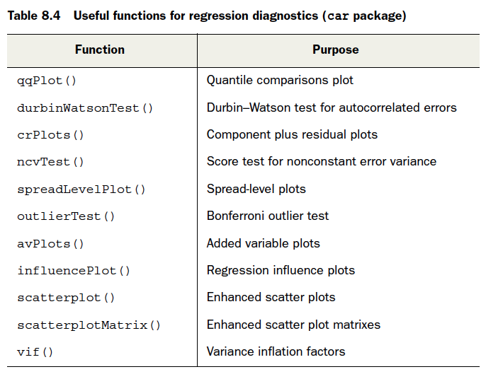

- Normalidad
- Linealidad
- Varianza Constante. Homocedasticidad
- Validación Global
- Multicolinealidad
- Observaciones anómalas

#### Ejemplo: Advertising

> En el fichero `Advertising.csv` se encuentran los resultados de 200 campañas de publicidad de una entidad financiera.
> - La variable `Sales` representa el número de productos que han vendido en la campaña en miles (p.e. el número de fondos de inversión, de depósitos o de cuentas corrientes).
> - Las variables `TV`, `Radio` y `Newspaper` los gastos en miles de euros de las respectivas campañas de publicidad.

> Hay importantes preguntas que queremos contestar mediante el modelo de regresión:
> - ¿Hay una relación entre el presupuesto de publicidad y las Ventas?
> - ¿Cómo de fuerte es la relación entre los gastos de publicidad y las ventas?
> - ¿Cuál de los los medios contribuye más a las ventas?
> - ¿Cómo de precisos se pueden estimar los efectos de cada medio sobre las ventas?
> - ¿Cómo de preciso se pueden predecir las ventas futuras?
> - ¿Es la relación lineal?
> - ¿Hay sinergias entre los diferentes tipos de anuncios?

```r
mData=read.csv("./Datos/Advertising.csv")
regres01=lm(Sales~TV+Radio+Newspaper,data=mData)
summary(regres01)
```

```
##
## Call:
## lm(formula = Sales ~ TV + Radio + Newspaper, data = mData)
##
## Residuals:
##     Min      1Q  Median      3Q     Max
## -8.8277 -0.8908  0.2418  1.1893  2.8292
##
## Coefficients:
##              Estimate Std. Error t value Pr(>|t|)
## (Intercept)  2.938889   0.311908   9.422   <2e-16 ***
## TV           0.045765   0.001395  32.809   <2e-16 ***
## Radio        0.188530   0.008611  21.893   <2e-16 ***
## Newspaper   -0.001037   0.005871  -0.177     0.86
## ---
## Signif. codes:  0 '***' 0.001 '**' 0.01 '*' 0.05 '.' 0.1 ' ' 1
##
## Residual standard error: 1.686 on 196 degrees of freedom
## Multiple R-squared:  0.8972, Adjusted R-squared:  0.8956
## F-statistic: 570.3 on 3 and 196 DF,  p-value: < 2.2e-16
```

## Normalidad

##### qqplot

Un QQ-plots (quantile vs quantile plots) es una representación gráfica, que sirve para comparar dos distribuciones y ver si coinciden. En realidad, para comprobar si un conjunto de datos muestrales están generados por una distribución teórica como la normal , la exponencial, …

Un QQ-plot es un gráfico de puntos que muestra los cuantiles. Si ambos cuantiles viene de la misma distribución, veremos que los puntos forman una linea recta, sino esto no ocurre entenderemos que los datos muestrales no han sido generados por la distribución teórica. Al gráfico de puntos se le puede añdir un intervalo de confianza.

##### Creando un qq-plot

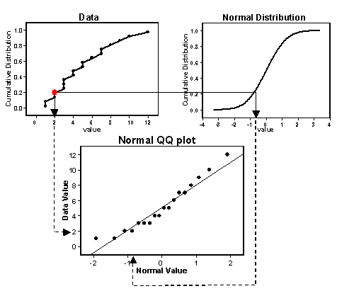

##### Interpretación del qq-plot

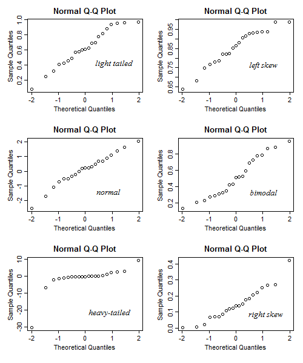

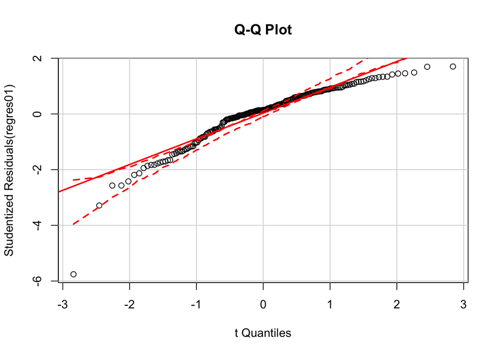

```r
library(car)
qqPlot(regres01, labels=row.names(mData), id.method="identify",
       simulate=TRUE, main="Q-Q Plot")
```

#### Histograma + densidad + normal + rug

- ¿Qué son los `Studentized Residual`?
- ¿La media de los residuos y la constante?
- ¿Diferencia entre histograma y densidad?

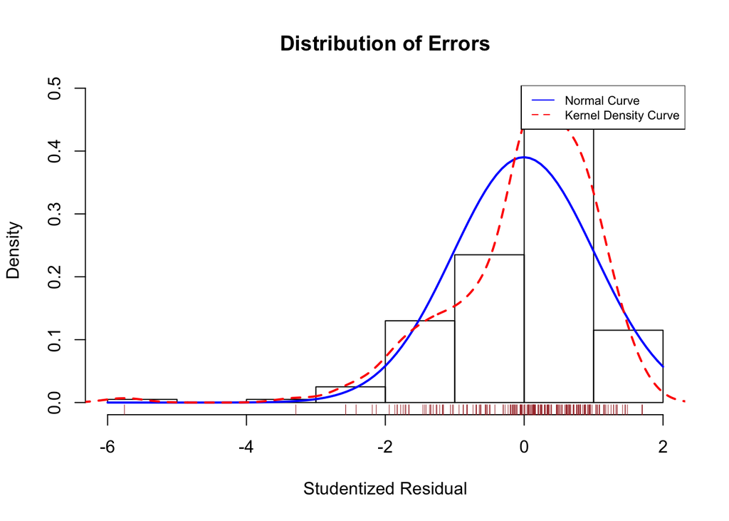

```r
residplot <- function(fit, nbreaks=10) {
  z <- rstudent(fit)
  hist(z, breaks=nbreaks, freq=FALSE,
       xlab="Studentized Residual",
       main="Distribution of Errors")
  rug(jitter(z), col="brown")
  curve(dnorm(x, mean=mean(z), sd=sd(z)),
        add=TRUE, col="blue", lwd=2)
  lines(density(z)$x, density(z)$y,
        col="red", lwd=2, lty=2)
  legend("topright",
         legend = c( "Normal Curve", "Kernel Density Curve"),
         lty=1:2, col=c("blue","red"), cex=.7)
}

residplot(regres01)
```

#### Jarque Bera

El contraste de normalidad de Jarque-Bera consiste en

$$\mathit{JB} = \frac{n-k+1}{6} \left( S^2 + \frac14 (C-3)^2 \right)$$

Donde $n$ es el número de observaciones; $S$ es el coeficiente de asimetría muestral; $C$ es la curtosis muestral y k es el número de regresores:

$$S = \frac{ \hat{\mu}_3 }{ \hat{\sigma}^3 }
= \frac{\frac1n \sum_{i=1}^n (x_i-\bar{x})^3} {\left(\frac1n \sum_{i=1}^n (x_i-\bar{x})^2 \right)^{3/2}} ,$$
$$C = \frac{ \hat{\mu}_4 }{ \hat{\sigma}^4 }
= \frac{\frac1n \sum_{i=1}^n (x_i-\bar{x})^4} {\left(\frac1n \sum_{i=1}^n (x_i-\bar{x})^2 \right)^{2}} ,$$

El estadístico se distribuye como una chi-cuadrado de 2 grados de libertad, siendo *la hipótesis nula* que la distribución es normal (coeficiente de asimetría y curtosis es cero)

```r
vResid=resid(regres01)
library(fBasics)
jbTest(vResid)
```

```
##
## Title:
##  Jarque - Bera Normality Test
##
## Test Results:
##   PARAMETER:
##     Sample Size: 200
##   STATISTIC:
##     LM: 151.241
##     ALM: 161.997
##   P VALUE:
##     Asymptotic: < 2.2e-16
##
## Description:
##  Mon Nov 28 01:25:41 2016 by user:
```

#### Shapiro-Wilk

El test de Shapiro-Wilk permite comprobar si una muestra ha sido generada por un distribución normal.

$$W = {\left(\sum_{i=1}^n a_i x_{(i)}\right)^2 \over \sum_{i=1}^n (x_i-\overline{x})^2},$$

donde

$x_{(i)}$ es el número que ocupa la i-ésima posición en la muestra;

$\overline{x} = \left( x_1 + \cdots + x_n \right) / n$ es la media muestral;

$a_i$ se obtiene de:

$$(a_1,\dots,a_n) = {m^{\mathsf{T}} V^{-1} \over (m^{\mathsf{T}} V^{-1}V^{-1}m)^{1/2}},$$
donde

$m = (m_1,\dots,m_n)^{\mathsf{T}}$,

$m_1,\ldots,m_n$ son los valores medios del estadístico ordenado, de variables aleatorias independientes e idénticamente distribuidas, muestreadas de distribuciones normales. $V$ es la matriz de covarianzas de ese estadístico de orden.

```r
shapiro.test(vResid)
```

```
##
##  Shapiro-Wilk normality test
##
## data:  vResid
## W = 0.91767, p-value = 3.939e-09
```

#### Linealidad

##### Componentes o Gráficos de residuos parciales

Se grafican los valores ajustados con respecto a los predictores, si no hay problemas de linealidad se obtiene un recta sobre las que se representan los puntos.

Los gráficos se incluyen una estimación suavizada (verde) que debería aproximarse a la linea recta (roja).

$${Residuos} + \hat{\beta}_iX_i \mathrm{\ versus\ } X_i$$

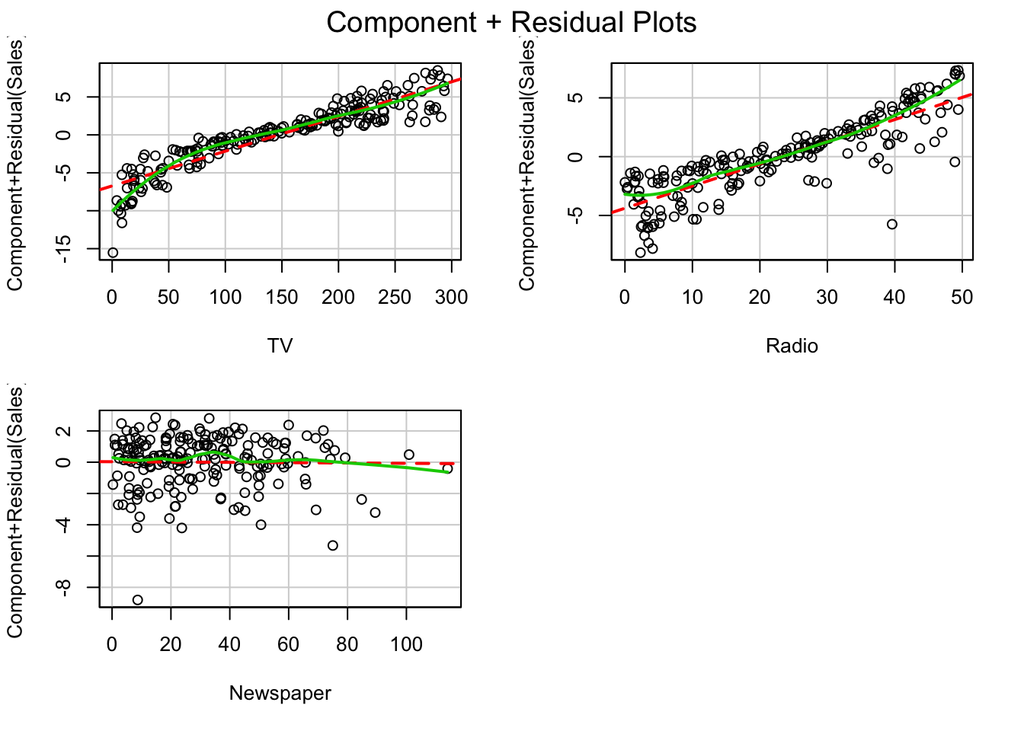

```r
crPlots(regres01)
```

#### Varianza Constante. Homocedasticidad

##### Varianza no constante (ncvtest) (Breusch-Pagan)

La hipótesis nula es que la varianza es constante.

El test Breusch–Pagan test esta basado sobre modelos del tipo $\sigma_i^2 = h(z_i'\gamma)$ para las varianzas de las observaciones, donde $z_i = (1, z_{2i}, \ldots, z_{pi})$ explican la varaibilidad de la varianza (la varianza no constante).

La hipótesis nula de ausencia de heterocedasticidad es equivalente a $(p - 1)$ restricciones de igualdad a cero de los parámetros:
$$\gamma_2 = \cdots = \gamma_p = 0.$$

El test es equivalente a un proceso en 3 etapas:

- *Etapa 1*: Aplicar MCO al modelo
  $$y = X\beta+\varepsilon.$$
  y calcular los residuos.
- *Etapa 2*: Realizar la regresión auxiliar:
  $$e_i^2=\gamma_1+\gamma_2z_{2i}+\cdots+\gamma_pz_{pi}+\eta_i.$$
  Siendo, $z$ sustituida por los regresores $x$. l
- *Etapa 3*: El estadístico de contraste es el $R^2$ de la regresión auxiliar multiplicado por el tamaño muestral $n$:
  $$\text{LM}=nR^2\, .$$

El estadístico se distribuye asintóticamente como una $\chi^2_{p - 1}$ bajo la hipótesis nula de homocedasticidad.

También se puede representar los residuos estandarizados absolutos versus los valores ajustados, se superpone la mejor linea recta que ajusta los datos. (Si se cumple la hipótesis de homocedasticidad se espera que la linea sea horizontal)

```r
ncvTest(regres01)
```

```
## Non-constant Variance Score Test
## Variance formula: ~ fitted.values
## Chisquare = 5.355982    Df = 1     p = 0.02065131
```

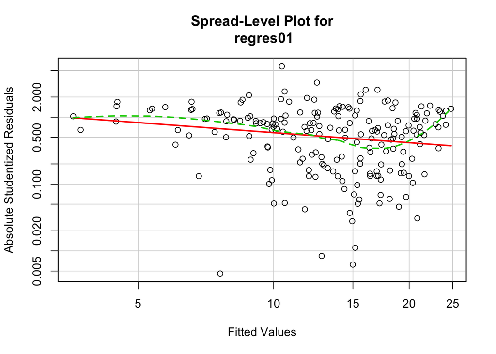

```
##
## Suggested power transformation:  1.499852
```

```r
spreadLevelPlot(regres01)
```

#### Validación Global

Podemos contrastar todas las hipótesis del modelo mediante el test de Peña, EA and Slate, EH (2006). “Global validation of linear model assumptions,” J.Amer. Statist. Assoc., 101(473):341-354.

```r
library(gvlma)
gvmodel <- gvlma(regres01)
summary(gvmodel)
```

```
##
## Call:
## lm(formula = Sales ~ TV + Radio + Newspaper, data = mData)
##
## Residuals:
##     Min      1Q  Median      3Q     Max
## -8.8277 -0.8908  0.2418  1.1893  2.8292
##
## Coefficients:
##              Estimate Std. Error t value Pr(>|t|)
## (Intercept)  2.938889   0.311908   9.422   <2e-16 ***
## TV           0.045765   0.001395  32.809   <2e-16 ***
## Radio        0.188530   0.008611  21.893   <2e-16 ***
## Newspaper   -0.001037   0.005871  -0.177     0.86
## ---
## Signif. codes:  0 '***' 0.001 '**' 0.01 '*' 0.05 '.' 0.1 ' ' 1
##
## Residual standard error: 1.686 on 196 degrees of freedom
## Multiple R-squared:  0.8972, Adjusted R-squared:  0.8956
## F-statistic: 570.3 on 3 and 196 DF,  p-value: < 2.2e-16
##
##
## ASSESSMENT OF THE LINEAR MODEL ASSUMPTIONS
## USING THE GLOBAL TEST ON 4 DEGREES-OF-FREEDOM:
## Level of Significance =  0.05
##
## Call:
##  gvlma(x = regres01)
##
##                       Value   p-value                   Decision
## Global Stat        197.3907 0.000e+00 Assumptions NOT satisfied!
## Skewness            58.7289 1.810e-14 Assumptions NOT satisfied!
## Kurtosis            92.5125 0.000e+00 Assumptions NOT satisfied!
## Link Function       45.9814 1.194e-11 Assumptions NOT satisfied!
## Heteroscedasticity   0.1678 6.820e-01    Assumptions acceptable.
```

#### Multicolinealidad

Es la existencia de alta correlación entre los predictores puede producir problemas de imprecisión de los estimadores (las varianzas de los estimadores son mayores de lo que deberían ser). Así, los intervalos de confianza son muy anchos, hay dificultad para interpretar los coeficientes y se tiende a no rechazar las hipótesis nula de significación.

El caso más extremo es cuando dos regresores son combinación lineal, en este caso no se puede obtener el estimador.

En algunas ocasiones el añadir nuevos datos, el valor de los estimadores cambian bastante, entonces seguramente es causado por la multicolinealidad.

##### Detección de la multicolinealidad

###### Método del Factor de Inflación de la Varianza

Para detectar la multicolinealidad se utiliza el `Factor de inflación de varianza (VIF)`.

Se define como:

$$FIV (\beta_j)= \frac{1}{1-R^2_{j}} \longleftrightarrow Tolerancia(\beta_j) = 1-R^2_{j}$$

Donde $R^2_{j}$ es el coeficiente de determinación de la regresión del regresor $j$ con respecto a todos los demas regresores.

Para cualquier regresor la raíz del VIF indica cuantas veces es la varianza del estimador es mayor que la que se obtendría si no hubiera correlación entre los regresores. Cuando $\sqrt{VIF}>2$ se considera que hay problemas de multicolinealidad.

```r
vif(regres01)
```

```
##        TV     Radio Newspaper
##  1.004611  1.144952  1.145187
```

```r
sqrt(vif(regres01)) > 2 # problem?
```

```
##        TV     Radio Newspaper
##     FALSE     FALSE     FALSE
```

#### Observaciones anómalas

```
(1) Atípicos:
Una observación es atípica si el residuo asociado es grande.
(2) Extrema o Apalancada:
Una observación es extrema (o potencialmente influyente o apalancada) si se encuentra apreciablemente alejada del resto de observaciones de la muestra.
(3) Influyente:
Una observación es influyente si la presencia de dicha observación en la muestra altera significativamente algún aspecto de la estimación del modelo.
```

Identificamos los valores atípicos mediante un Bonferroni p-values. En este caso solo contrasta el mayor de los residuos, si se rechaza que sea atípico se concluye que no hay atípicos.

También se puede realizar un gráfico de los residuos estandarizados con $\pm 2\sigma$.

```r
# Assessing outliers

outlierTest(regres01)
```

```
##      rstudent unadjusted p-value Bonferonni p
## 131 -5.757983          3.267e-08    6.534e-06
```

Para determinar valores extremos, se calcula el `hat statistic`, siendo la media $p/n$ donde $p$ es el número de parámetros estimados y $n$ el tamaño muestral. Las observaciones con un valor (2 o 3 veces la media) `hat` alto se consideran extremas.

Dado el estimador:
$$\hat{\boldsymbol \beta} = \left( \mathbf{X}^{\mathsf{T}} \mathbf{X} \right)^{-1} \mathbf{X}^{\mathsf{T}} \mathbf{y}$$

Los valores ajustados son:
$$\hat{\mathbf{y}} = \mathbf{X} \hat{\boldsymbol \beta} = \mathbf{X} \left( \mathbf{X}^{\mathsf{T}} \mathbf{X} \right)^{-1} \mathbf{X}^{\mathsf{T}} \mathbf{y}$$

Entonces la matriz de proyección (hat matrix) es:
$$\mathbf{H} = \mathbf{P} \equiv \mathbf{X} \left(\mathbf{X}^{\mathsf{T}} \mathbf{X} \right)^{-1} \mathbf{X}^{\mathsf{T}}$$

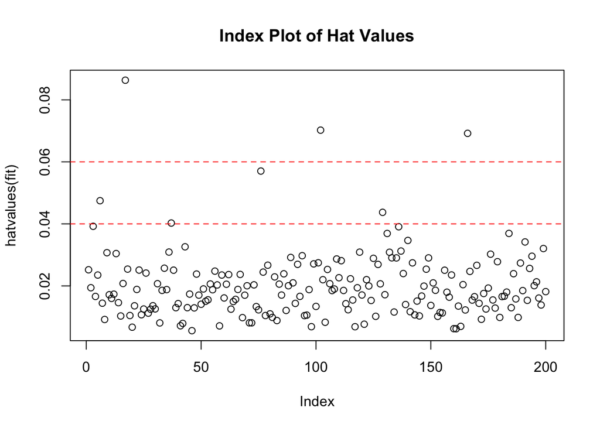

```
## integer(0)
```

```r
#  Identifying high leverage points
hat.plot <- function(fit) {
  p <- length(coefficients(fit))
  n <- length(fitted(fit))
  plot(hatvalues(fit), main="Index Plot of Hat Values")
  abline(h=c(2,3)*p/n, col="red", lty=2)
  identify(1:n, hatvalues(fit), names(hatvalues(fit)))
}
hat.plot(regres01)
```

Hay dos métodos par identificar observaciones influyentes:

- La distancia de Cook (D-estadístico)

Valores de D mayores que $\frac{4}{(n-k-1)}$ indican que son variables influyentes.

Ayuda a identificar los valores influyentes pero no indica como afectan al modelo.

- Gráficos `added variable`

Para cada regresor $X_k$, se grafican los residuos de la regresión de $y$ sobre todos los regresores menos $X_k$ y los residuos de la regresión de $X_k$ con los otros regresores.

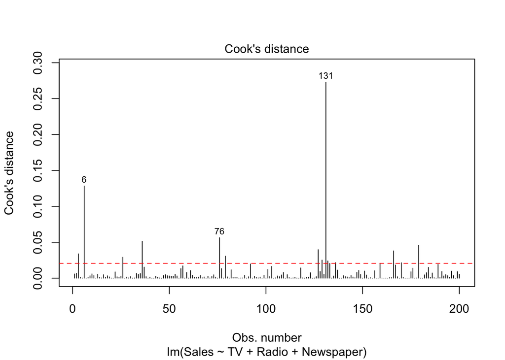

```r
# Identifying influential observations

# Cooks Distance D
# identify D values > 4/(n-k-1)
cutoff <- 4/(nrow(mData)-length(regres01$coefficients)-2)
plot(regres01, which=4, cook.levels=cutoff)
abline(h=cutoff, lty=2, col="red")
```

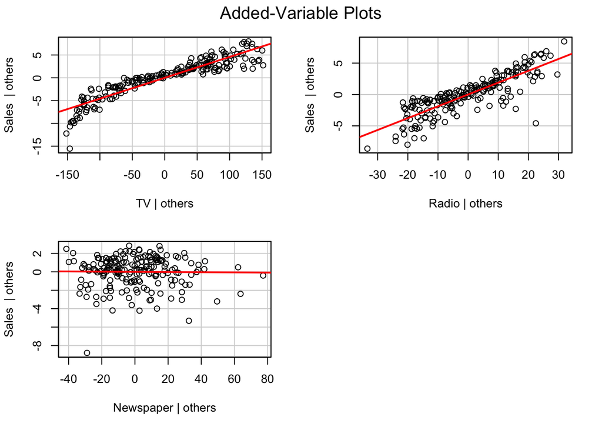

```r
# Added variable plots
# add id.method="identify" to interactively identify points
avPlots(regres01, ask=FALSE, id.method="identify")
```

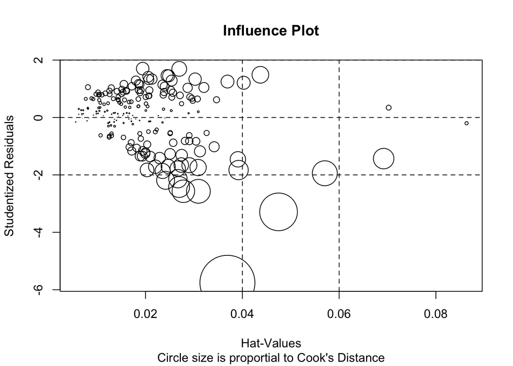

```r
# Influence Plot
influencePlot(regres01, id.method="identify", main="Influence Plot",
              sub="Circle size is proportial to Cook's Distance" )
```

# Selección de Variables

#### Comparando modelos

Se pueden comparar modelos `anidados` mediante análisis de varianza (anova). Dos modelos serán anidados si uno de los modelos contiene todo las variables del otro.

El modelo 1 está anidado dentro del modelo 2. Al ser el valor p alto, se considera que el modelo 1 no se puede rechazar.

```r
regres02=lm(Sales~TV+Radio,data=mData)
anova(regres02, regres01)
```

```
## Analysis of Variance Table
##
## Model 1: Sales ~ TV + Radio
## Model 2: Sales ~ TV + Radio + Newspaper
##   Res.Df    RSS Df Sum of Sq      F Pr(>F)
## 1    197 556.91
## 2    196 556.83  1  0.088717 0.0312 0.8599
```

Los criterios que se utilizan para seleccionar modelos son:

- $R^2$: no es un buen criterio al aumentar cuando se aumenta el número de regresores.
- $R^2$ ajustado: mejor. Penaliza la inclusión de regresores.
- Mallow’s Cp.

$$C_p=\frac{1}{n}(RSS + 2d\hat{\sigma}^2)$$
Donde

- $RSS$ es la `residual sum of squares`.
- $d$ es en número de predictores.
- y $\hat{\sigma}^2$ se refiere a la estimación de la varianza de los residuos.

Se selecciona el modelo con menor $C_p$

- Akaike’s Information Criterion(AIC)

$$AIC=\frac{1}{n\sigma^2}(RSS + 2d\hat{\sigma}^2)$$
Se selecciona el modelo con menor $AIC$

- Schwarz’s BIC

$$BIC=\frac{1}{n}(RSS + \log(n)d\hat{\sigma}^2)$$

Se selecciona el modelo con menor $BIC$

```r
AIC(regres01,regres02)
```

```
##          df      AIC
## regres01  5 782.3622
## regres02  4 780.3941
```

```r
BIC(regres01,regres02)
```

```
##          df      BIC
## regres01  5 798.8538
## regres02  4 793.5874
```

## Métodos de Selección

- Selección Best Subset
- Selección Stepwise
  - Forward Stepwise
  - Backward Stepwise
  - Mixto

#### Best Subset

Consiste en estimar todas las regresiones posibles con las combinaciones de los $p$ regresores.

Esto es, primero estimamos los $p$ modelos con las variables individuales, todos los modelos ${p \choose 2} =\frac{p(p-1)}{2}$con dos variables, luego los de tres variables y así hasta que están todas.

El algoritmo sería:

> 1.- Consideremos $\mathcal{M}_0$ el modelo nulo, que no contiene regresores. Este modelo predice la variable con su media.

> 2.- Para $k = 1, 2,\dots,p$
> 1. Se estiman ${p \choose k}$ modelos que contienen exactamente $k$ predictores.
> 2. Se elige el mejor de estos ${p \choose k}$ modelos y se le llama $\mathcal{M}_k$. Aqui el mejor modelo se selecciona con el menor RSS o su equivalente mayor $R^2$.

> 3.- Se selecciona un único modelo de los $\mathcal{M}_0, \dots \mathcal{M}_p$, utilizando $C_p, AIC, BIC \; ó \;\bar R^2$

```r
library (leaps)
regfit.full=regsubsets(Sales~.-X,mData )
reg.summary=summary(regfit.full)
reg.summary
```

```
## Subset selection object
## Call: regsubsets.formula(Sales ~ . - X, mData)
## 3 Variables  (and intercept)
##           Forced in Forced out
## TV            FALSE      FALSE
## Radio         FALSE      FALSE
## Newspaper     FALSE      FALSE
## 1 subsets of each size up to 3
## Selection Algorithm: exhaustive
##          TV  Radio Newspaper
## 1  ( 1 ) "*" " "   " "
## 2  ( 1 ) "*" "*"   " "
## 3  ( 1 ) "*" "*"   "*"
```

```r
reg.summary$rss
```

```
## [1] 2102.5306  556.9140  556.8253
```

```r
reg.summary$cp
```

```
## [1] 544.081354   2.031228   4.000000
```

```r
reg.summary$aic
```

[output not shown]

```r
reg.summary$bic
```

```
## [1] -178.6890 -439.0879 -433.8214
```

#### Forward Stepwise

Empieza con un modelo que no incluye ningún regresor y se van añadiendo regresores de uno en uno.

En cada etapa la variable que más mejora adicional aporta al modelo es incluida.

El algoritmo sería:

> 1.- Consideremos $\mathcal{M}_0$ el modelo nulo, que no contiene regresores.

> 2.- Para $k = 0, 2,\dots,p-1$
> 1. Se estiman todos los$p-k$ modelos que aumentan de predictores a $\mathcal{M}_k$ con un solo predictor adicional.
> 2. Se elige el mejor de estos $p-k$ modelos y se le llama $\mathcal{M}_k+1$. Aquí el mejor modelo se selecciona con el menor RSS o su mayor $R^2$.

> 3.- Se selecciona un único modelo de los $\mathcal{M}_0, \dots \mathcal{M}_p$, utilizando $C_p, AIC, BIC \; ó \;\bar R^2$

Con 20 variables en un caso serían 1.048.576 modelos y en el otro solo 211.

```r
library(MASS)

regfit.fwd=regsubsets(Sales~.-X,mData,method ="forward")
summary (regfit.fwd )
```

```
## Subset selection object
## Call: regsubsets.formula(Sales ~ . - X, mData, method = "forward")
## 3 Variables  (and intercept)
##           Forced in Forced out
## TV            FALSE      FALSE
## Radio         FALSE      FALSE
## Newspaper     FALSE      FALSE
## 1 subsets of each size up to 3
## Selection Algorithm: forward
##          TV  Radio Newspaper
## 1  ( 1 ) "*" " "   " "
## 2  ( 1 ) "*" "*"   " "
## 3  ( 1 ) "*" "*"   "*"
```

#### Backward Stepwise

Empieza con un modelo que incluye todos los regresores y se van eliminando regresores de uno en uno.

En cada etapa la variable que menos mejora adicional aporta al modelo es excluida.

El algoritmo sería:

> 1.- Consideremos $\mathcal{M}_p$ el modelo completo, que contiene todos los regresores.

> 2.- Para $k = p,p-1,\dots,1$
> 1. Se estiman todos los $k$ modelos que contienen todos menos un predictor en $\mathcal{M}_k$, par un toal de $k-1$ predictores.
> 2. Se elige el mejor de estos $k$ modelos y se le llama $\mathcal{M}_k-1$. Aquí el mejor modelo se selecciona con el menor RSS o su mayor $R^2$.

> 3.- Se selecciona un único modelo de los $\mathcal{M}_0, \dots \mathcal{M}_p$, utilizando $C_p, AIC, BIC \; ó \;\bar R^2$

Tanto los Forward como los Backward no garantiza la selección del modelo Best.

Se pueden utilizar modelos mixtos.

```r
library(MASS)

stepAIC(regres01, direction="backward")
```

```
## Start:  AIC=212.79
## Sales ~ TV + Radio + Newspaper
##
##             Df Sum of Sq    RSS    AIC
## - Newspaper  1      0.09  556.9 210.82
## <none>                    556.8 212.79
## - Radio      1   1361.74 1918.6 458.20
## - TV         1   3058.01 3614.8 584.90
##
## Step:  AIC=210.82
## Sales ~ TV + Radio
##
##         Df Sum of Sq    RSS    AIC
## <none>                556.9 210.82
## - Radio  1    1545.6 2102.5 474.52
## - TV     1    3061.6 3618.5 583.10
```

```
##
## Call:
## lm(formula = Sales ~ TV + Radio, data = mData)
##
## Coefficients:
## (Intercept)           TV        Radio
##     2.92110      0.04575      0.18799
```

```r
regfit.bwd=regsubsets(Sales~.-X,mData,method ="backward")
summary (regfit.bwd )
```

```
## Subset selection object
## Call: regsubsets.formula(Sales ~ . - X, mData, method = "backward")
## 3 Variables  (and intercept)
##           Forced in Forced out
## TV            FALSE      FALSE
## Radio         FALSE      FALSE
## Newspaper     FALSE      FALSE
## 1 subsets of each size up to 3
## Selection Algorithm: backward
##          TV  Radio Newspaper
## 1  ( 1 ) "*" " "   " "
## 2  ( 1 ) "*" "*"   " "
## 3  ( 1 ) "*" "*"   "*"
```

```r
stepAIC(regres01, direction="both")
```

```
## Start:  AIC=212.79
## Sales ~ TV + Radio + Newspaper
##
##             Df Sum of Sq    RSS    AIC
## - Newspaper  1      0.09  556.9 210.82
## <none>                    556.8 212.79
## - Radio      1   1361.74 1918.6 458.20
## - TV         1   3058.01 3614.8 584.90
##
## Step:  AIC=210.82
## Sales ~ TV + Radio
##
##             Df Sum of Sq    RSS    AIC
## <none>                    556.9 210.82
## + Newspaper  1      0.09  556.8 212.79
## - Radio      1   1545.62 2102.5 474.52
## - TV         1   3061.57 3618.5 583.10
```

```
##
## Call:
## lm(formula = Sales ~ TV + Radio, data = mData)
##
## Coefficients:
## (Intercept)           TV        Radio
##     2.92110      0.04575      0.18799
```

# Cross Validation

Es importante separa la muestra en dos partes:

- Training: estimaremos el modelo y obtendremos los valores ajustados que se comparan los valores reales. A partir de aquí se calculan los residuos. `Training Error`
- Testing: Se predice con el modelo y se comparan las predicciones con los valores reales obteniendo los errores de predicción. `Test error`

#### Validation Set

Consiste en dividir la muestra de forma aleatoria en dos submuestras. Utilizar una para el training (se estima el modelo) y la otra para el testing (se predice el modelo).

Esta selección se realiza repetidamente.

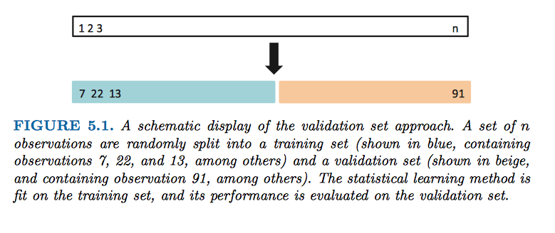

```r
library(ISLR)
set.seed(250)
numData=nrow(mData)
train=sample(numData ,numData/2)

regres.train =lm(Sales~.-X,mData ,subset =train )
attach(mData)
mean((Sales-predict(regres.train ,Auto))[-train ]^2)
```

```
## [1] 2.991664
```

```r
set.seed(251)
regres.train2 =lm(Sales~.-X-Newspaper,mData,subset =train )
mean((Sales-predict(regres.train2 ,Auto))[-train ]^2)
```

```
## [1] 2.823357
```

#### Leave-One-Out Cross-Validation

El Leave-One-Out Cross-Validation (LOOCV) consiste en tomar una muestra con todos los datos menos uno. Se estima el modelo y se predice sobre el dato que se ha dejado fuera. Este proceso se repite para los $n$ datos.

En este caso el estimador del `test error` es:

$$CV_{(n)}=\frac{1}{n} \sum_{i=1}^{n}MSE_i$$

Es el método que menor error comete al estimar el test error. Sin embargo tiene un coste computacional alto.

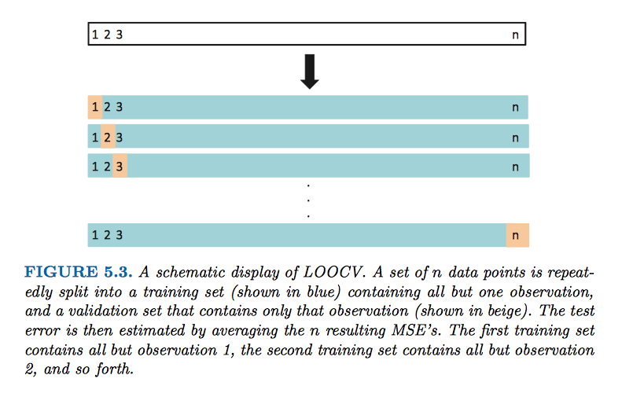

```r
glm.fit1=glm(Sales~.-X,mData,family = gaussian())
coef(glm.fit1)
```

```
##  (Intercept)           TV        Radio    Newspaper
##  2.938889369  0.045764645  0.188530017 -0.001037493
```

```r
library (boot)
cv.err =cv.glm(mData,glm.fit1)
cv.err$delta
```

```
## [1] 2.946900 2.946486
```

```r
glm.fit2=glm(Sales~.-X-Newspaper,mData,family = gaussian())
cv.err2 =cv.glm(mData,glm.fit2)
cv.err2$delta
```

```
## [1] 2.910676 2.910357
```

#### K-Fold Cross-Validation

Supone dividir la muestra en $k$ grupos o folds, de aproximadamente igual tamaño. Cada folds es tratado como un conjunto de validación, de tal forma que se estima el modelo con los datos que no están el fold (los otros $k-1$ folds) y se predicen en el fold.

El procedimiento se repite k veces y se estima el error:

$$CV_{(k)}=\frac{1}{k} \sum_{i=1}^{k}MSE_i$$

El LOOCV es un caso especial del K-fold en el cual $k=n$.

Los calores habituales para la $k$ suelen ser 5 o 10.

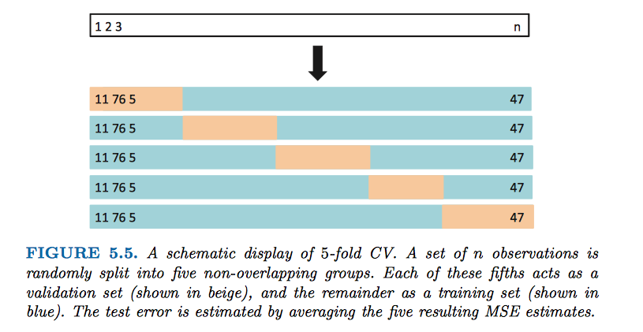

```r
glm.fit1=glm(Sales~.-X,mData,family = gaussian())


library (boot)
cv.err =cv.glm(mData,glm.fit1,K=10)
cv.err$delta
```

```
## [1] 2.934905 2.926889
```

```r
glm.fit2=glm(Sales~.-X-Newspaper,mData,family = gaussian())
cv.err2 =cv.glm(mData,glm.fit2,K=10)
cv.err2$delta
```

```
## [1] 2.891888 2.886227
```

### Importancia relativa

*¿Cuál variable es más útil o importante para predecir la variable dependiente?*

Lo que se hace es calcular los estimadores estandarizados.

```r
zData=data.frame(scale(mData))
zlm.fit=lm(Sales~.-X-Newspaper,zData)
coef(zlm.fit)
```

```
##   (Intercept)            TV         Radio
## -8.665545e-17  7.529042e-01  5.349569e-01
```

Un aumento en una desviación típica de los gastos en publicidad en TV supone que las ventas se incrementan en 0.752 desviaciones típicas.

### Datos Ausentes

```r
library(rminer)
nelems=function(d) paste(nrow(d),"x",ncol(d))
#missing Data
# missing data example
# since sale does not include missing data, lets
# synthetically create such data:
set.seed(12345) # set for replicability
mData3=mData
N=20 # randomly assign N missing values (NA) to 2nd and 3rd attributes
srow1=sample(1:nrow(mData),N) # N rows
srow2=sample(1:nrow(mData),N) # N rows
mData3[srow1,2]=NA # tv
mData3[srow2,3]=NA # radio
print("Show summary of sales attributes (with NA values):")
```

```
## [1] "Show summary of sales attributes (with NA values):"
```

```r
print(summary(mData3[,1:2]))
```

```
##        X                TV
##  Min.   :  1.00   Min.   :  0.70
##  1st Qu.: 50.75   1st Qu.: 74.38
##  Median :100.50   Median :154.05
##  Mean   :100.50   Mean   :147.30
##  3rd Qu.:150.25   3rd Qu.:218.43
##  Max.   :200.00   Max.   :296.40
##                   NA's   :20
```

```r
cat("mData3:",nelems(mData3),"\n")
```

```
## mData3: 200 x 5
```

```r
cat("NA values:",sum(is.na(mData3)),"\n")
```

```
## NA values: 40
```

```r
# 1st method: case deletion
print("-- 1st method: case deletion --")
```

```
## [1] "-- 1st method: case deletion --"
```

```r
mData4=na.omit(mData3)
cat("mData4:",nelems(mData4),"\n")
```

```
## mData4: 162 x 5
```

```r
cat("NA values:",sum(is.na(mData4)),"\n")
```

```
## NA values: 0
```

```r
# 2nd method: average imputation for tv, mode imputation for radio:
# substitute NA values by the mean:
print("-- 2nd method: value imputation --")
```

```
## [1] "-- 2nd method: value imputation --"
```

```r
print("original tv summary:")
```

```
## [1] "original tv summary:"
```

```r
print(summary(mData3$TV))
```

```
##    Min. 1st Qu.  Median    Mean 3rd Qu.    Max.    NA's
##    0.70   74.38  154.00  147.30  218.40  296.40      20
```

```r
meanTV=mean(mData3$TV,na.rm=TRUE)
mData5=imputation("value",mData3,"TV",Value=meanTV)
print("mean imputation TV summary:")
```

```
## [1] "mean imputation TV summary:"
```

```r
print(summary(mData5$TV))
```

```
##    Min. 1st Qu.  Median    Mean 3rd Qu.    Max.
##    0.70   76.38  147.30  147.30  214.90  296.40
```

```r
# substitute NA values by the mode (most common value of mData$radio):
print("original Radio summary:")
```

```
## [1] "original Radio summary:"
```

```r
print(summary(mData3$Radio))
```

```
##    Min. 1st Qu.  Median    Mean 3rd Qu.    Max.    NA's
##    0.30   10.48   23.75   23.60   36.52   49.60      20
```

```r
mData5=imputation("value",mData5,"Radio",Value=(which.max(table(mData$Radio))))
print("mode imputation Radio summary:")
```

```
## [1] "mode imputation Radio summary:"
```

```r
print(summary(mData5$Radio))
```

```
##    Min. 1st Qu.  Median    Mean 3rd Qu.    Max.
##    0.30   11.68   20.55   23.24   35.18   49.60
```

```r
# 3rd method: hot deck
# substitute NA values by the values found in most similar case (1-nearest neighbor):
print("-- 3rd method: hotdeck imputation --")
```

```
## [1] "-- 3rd method: hotdeck imputation --"
```

```r
print("original Radio summary:")
```

```
## [1] "original Radio summary:"
```

```r
print(summary(mData3$TV))
```

```
##    Min. 1st Qu.  Median    Mean 3rd Qu.    Max.    NA's
##    0.70   74.38  154.00  147.30  218.40  296.40      20
```

```r
mData6=imputation("hotdeck",mData3,"TV")
print("hot deck imputation age summary:")
```

```
## [1] "hot deck imputation age summary:"
```

```r
print(summary(mData6$TV))
```

```
##    Min. 1st Qu.  Median    Mean 3rd Qu.    Max.
##    0.70   74.38  154.00  147.30  218.40  296.40
```

```r
# substitute NA values by the values found in most similar case:
print("original Radio summary:")
```

```
## [1] "original Radio summary:"
```

```r
print(summary(mData3$Radio))
```

```
##    Min. 1st Qu.  Median    Mean 3rd Qu.    Max.    NA's
##    0.30   10.48   23.75   23.60   36.52   49.60      20
```

```r
mData6=imputation("hotdeck",mData6,"Radio")
print("hot deck imputation Radio summary:")
```

```
## [1] "hot deck imputation Radio summary:"
```

```r
print(summary(mData6$Radio))
```

```
##    Min. 1st Qu.  Median    Mean 3rd Qu.    Max.
##   0.300   9.975  22.400  23.050  35.450  49.600
```

```r
cat("mData6:",nelems(mData6),"\n")
```

```
## mData6: 200 x 5
```

```r
cat("NA values:",sum(is.na(mData6)),"\n")
```

```
## NA values: 0
```

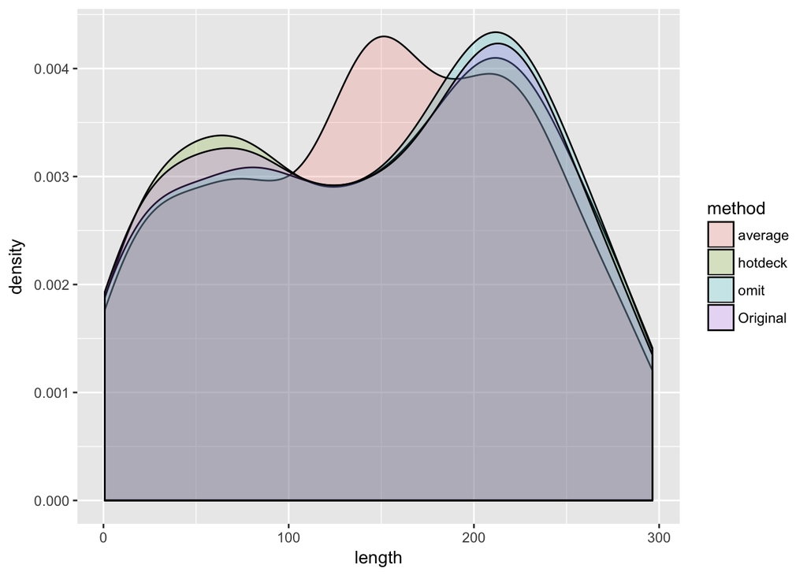

```r
# comparison of age densities (mean vs hotdeck):
library(ggplot2)
meth1=data.frame(length=mData4$TV)
meth2=data.frame(length=mData5$TV)
meth3=data.frame(length=mData6$TV)
meth0=data.frame(length=mData3$TV)
meth1$method="omit"
meth2$method="average"
meth3$method="hotdeck"
meth0$method="Original"
all=rbind(meth1,meth2,meth3,meth0)
ggplot(all,aes(length,fill=method))+geom_density(alpha = 0.2)
```

#### Ejemplo: Advertising

> Hay importantes preguntas que queremos contestar mediante el modelo de regresión:
> - ¿Hay una relación entre el presupuesto de publicidad y las Ventas?
> - ¿Cómo de fuerte es la relación entre los gastos de publicidad y las ventas?
> - ¿Cuál de los los medios contribuye más a las ventas?
> - ¿Cómo de precisos se pueden estimar los efectos de cada medio sobre las ventas?
> - ¿Cómo de preciso se pueden predecir las ventas futuras?
> - ¿Es la relación lineal?
> - ¿Hay sinergias entre los diferentes tipos de anuncios?